clc;clear;

workingpath='/Volumes/WD_D/share/202007RM039 嗅觉实验/';

cd(workingpath);

id=fopen('嗅觉实验记录.txt');

conditions=textscan(id,'%q','whitespace','\b\t');

conditions=conditions{1};

fclose(id);

files=dir('data*.csv');

alldata=cell(1,length(files));

% middle point

m=zeros(1,length(files));

for f=1:length(files)

% load data

filename=files(f).name;

% 从第二行第一列读取数据

data=csvread(filename,1,0);

m(f)=mean([min(data(:,2)) max(data(:,2))]);

disp([min(data(:,2)) mean([min(data(:,2)) max(data(:,2))]) max(data(:,2)) min(data(:,3)) mean([min(data(:,3)) max(data(:,3))]) max(data(:,3))])

data(:,3)=130-data(:,3);

% 绘制轨迹

% monkeyt(data(:,2),data(:,3),0.1,0.001);

% 查看分布情况

% length(data(data(:,2)>100,3));

% length(data(data(:,2)<=100,3));

%

% length(data(data(:,2)<=90,3));

% length(data(data(:,2)>=110,3));

%

% length(data(data(:,2)<=80,3));

% length(data(data(:,2)>=120,3));

% max(data(:,2));

% min(data(:,2));

% mean([max(data(:,2)),min(data(:,2))]);

%保存到cell中

alldata{f}=data;

end

7.3455 102.7772 198.2090 50.6509 85.9780 121.3050

38.7724 107.1697 175.5670 61.3887 82.6643 103.9400

37.8309 108.2765 178.7220 54.1094 79.1037 104.0980

38.3356 105.1518 171.9680 63.0501 83.0211 102.9920

## Scale

for f=1:length(files)

data=alldata{f};

mid=m(f);

minvalue=min(data(:,2));

maxvalue=max(data(:,2));

data(data(:,2)<=mid,2)=(data(data(:,2)<=mid,2)-minvalue)*100/(mid-minvalue);

data(data(:,2)>mid,2)=100+(data(data(:,2)>mid,2)-mid)*100/(maxvalue-mid);

alldata{f}=data;

end

## 绘制轨迹

% for f=1:length(files)

% data=alldata{f};

% figure;

% % 绘制轨迹

% % monkeyt(data(:,2),data(:,3),0.1,0.001);

% monkeyt(data(:,2),data(:,3),0,0);

% title(conditions{f});

% end

## 整体的直方图

interval=5;

for f=1:length(files)

data=alldata{f};

% chisq test

disp(conditions{f})

for i=0:10:20

cutl=100-i;

cutr=100+i;

disp([cutl cutr])

[pvalue,st]=chit(data,cutl,cutr)

end

figure;

% x方向的分布

subplot(1,2,1)

hist(data(:,2),interval/2:interval:200-interval/2);

line([100 100],get(gca,'Ylim'),'linestyle',':')

title('x')

% y方向的分布

subplot(1,2,2)

hist(data(:,3));

title('y')

suptitle(conditions{f});

end

20200708 左：香蕉 右：5%异戊酸

100 100

pvalue = 3.8276e-123

st =

chi2stat: 556.9738  
df: 1  
edges: [0 100 200]  
O: [29513 35532]  
E: [3.2522e+04 3.2522e+04]

90 110

pvalue = 1.8396e-123

st =

chi2stat: 558.4365  
df: 1  
edges: [0 100 200]  
O: [28794 34751]  
E: [3.1772e+04 3.1772e+04]

80 120

pvalue = 7.9095e-125

st =

chi2stat: 564.7187  
df: 1  
edges: [0 100 200]  
O: [27811 33705]  
E: [30758 30758]

20200709 左：白桃 右：吲哚

100 100

pvalue = 1.5446e-60

st =

chi2stat: 269.3855  
df: 1  
edges: [0 100 200]  
O: [42540 47464]  
E: [45002 45002]

90 110

pvalue = 9.2487e-69

st =

chi2stat: 307.1225  
df: 1  
edges: [0 100 200]  
O: [41586 46796]  
E: [44191 44191]

80 120

pvalue = 3.8071e-31

st =

chi2stat: 134.7172  
df: 1  
edges: [0 100 200]  
O: [39831 43175]  
E: [41503 41503]

20200715 左：5%异戊酸 右：香蕉

100 100

pvalue = 0

st =

chi2stat: 2.3001e+03  
df: 1  
edges: [0 100 200]  
O: [37808 52196]  
E: [45002 45002]

90 110

pvalue = 0

st =

chi2stat: 2.3247e+03  
df: 1  
edges: [0 100 200]  
O: [36899 51211]  
E: [44055 44055]

80 120

pvalue = 3.5946e-140

st =

chi2stat: 635.2562  
df: 1  
edges: [0 100 200]  
O: [34941 41929]  
E: [38435 38435]

20200716 左：吲哚 右：白桃

100 100

pvalue = 4.2543e-142

st =

chi2stat: 644.1158  
df: 1  
edges: [0 100 200]  
O: [48809 41195]  
E: [45002 45002]

90 110

pvalue = 1.1299e-143

st =

chi2stat: 651.3613  
df: 1  
edges: [0 100 200]  
O: [47907 40326]  
E: [4.4116e+04 4.4116e+04]

80 120

pvalue = 0

st =

chi2stat: 2.8628e+03  
df: 1  
edges: [0 100 200]  
O: [46396 31466]  
E: [38931 38931]

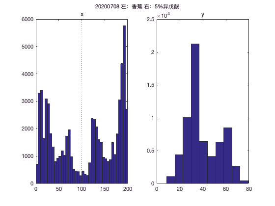

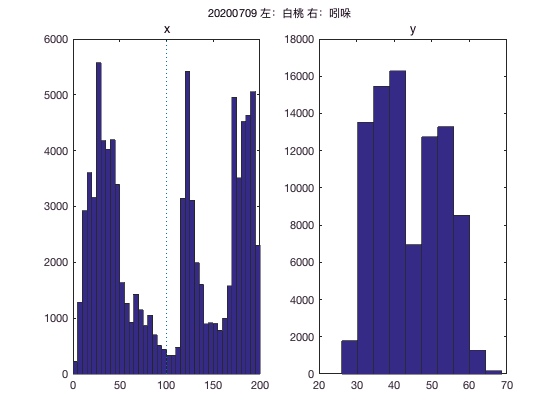

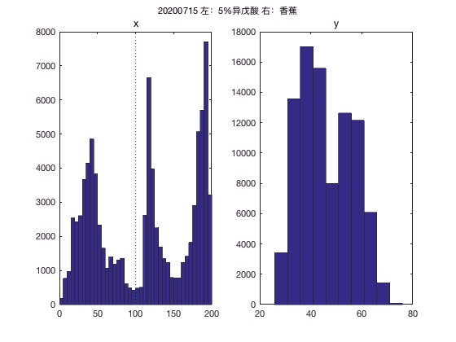

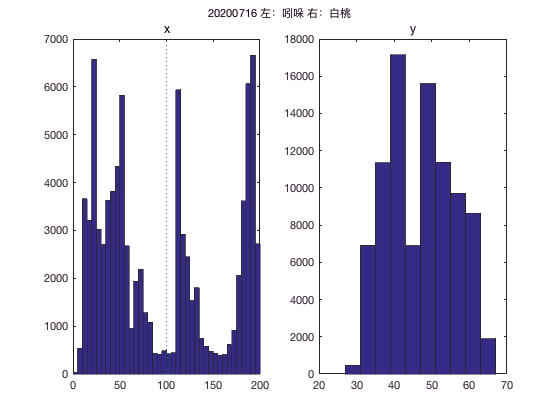

## 合并4个条件

tic;

interval=10;

data=[alldata{1};alldata{2};alldata{3};alldata{4}];

expect=zeros(3,2);

% chisq test

disp('4 days');

4 days

for i=0:10:20

cutl=100-i;

cutr=100+i;

disp([cutl cutr])

[pvalue,st]=chit(data,cutl,cutr)

expect(i/10+1,:)=st.O;

end

100 100

pvalue = 9.6646e-206

st =

chi2stat: 936.8319  
df: 1  
edges: [0 100 200]  
O: [158670 176387]  
E: [1.6753e+05 1.6753e+05]

90 110

pvalue = 3.2080e-214

st =

chi2stat: 975.8382  
df: 1  
edges: [0 100 200]  
O: [155186 173084]  
E: [164135 164135]

80 120

pvalue = 0.0178

st =

chi2stat: 5.6127  
df: 1  
edges: [0 100 200]  
O: [148979 150275]  
E: [149627 149627]

figure;

subplot(1,2,1)

hist(data(:,2),interval/2:interval:200-interval/2);

line([100 100],get(gca,'Ylim'),'linestyle',':')

title('x')

% y方向的分布

subplot(1,2,2)

hist(data(:,3));

title('y')

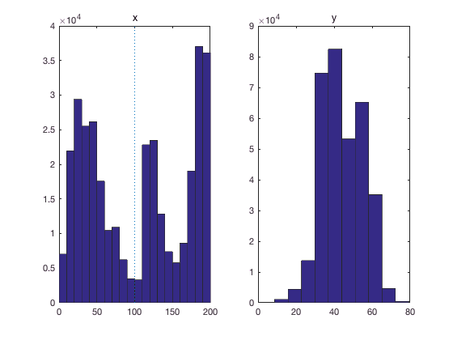

## 绘制热图

xx=data(:,2);

yy=data(:,3);

% sigma = 0.1;

gridSize = 100;

x=linspace(0,200,gridSize+1);

y=linspace(0,100,gridSize+1);

gridEval = zeros(length(x)-1,length(y)-1);

% 计算每个网格中点的频数

for cnt_x=1:length(x)-1

for cnt_y=1:length(y)-1

x_ind=xx>x(cnt_x) & xx<=x(cnt_x+1);

xy_ind=yy(x_ind)>y(cnt_y) & yy(x_ind)<=y(cnt_y+1);

gridEval(cnt_y, cnt_x)=length(yy(xy_ind));

end

end

% % 计算每个点处的高斯函数

% for i = 1:length(x)-1

% for j = 1:length(y)-1

% %calculate a Gaussian function on the grid with each point in the center and add them up

% gridEval(j,i) = gridEval(j,i) + sum(exp(-(((x(i)-xx).^2)./(2*sigma.^2) + ((y(j)-yy).^2)./(2*sigma.^2))));

% end

% end

% 绘制热图

figure;

surf((x(1:end-1)+ x(2:end))/2,(y(1:end-1)+y(2:end))/2,gridEval); view(2); shading interp;

% 增加z轴会变成三维的

% axis([0 200 0 100 0 100]);

axis([0 200 0 100])

h1 = gca; % 保存句柄，以便后面添加边框

set(gca, 'CLim', [0 400]);

% 添加标注

% title(['平滑散点图, \sigma = ' num2str(sigma) ', 网格数： ' num2str(gridSize) ' x' num2str(gridSize)],'Fontsize',14);

title(['网格数： ' num2str(gridSize) ' x' num2str(gridSize)]);

xlabel('x','Fontsize',14);

ylabel('y','Fontsize',14);

% 添加颜色条

colormap jet

colorbar;

ylabel('Intensity','Fontsize',14);

% 添加黑色的边框

axes(h1);

line(get(gca,'xlim'),repmat(min(get(gca,'ylim')),1,2),'color',[0 0 0],'linewidth',1);

line(get(gca,'xlim'),repmat(max(get(gca,'ylim')),1,2),'color',[0 0 0],'linewidth',2);

line(repmat(min(get(gca,'xlim')),1,2),get(gca,'ylim'),'color',[0 0 0],'linewidth',2);

line(repmat(max(get(gca,'xlim')),1,2),get(gca,'ylim'),'color',[0 0 0],'linewidth',1);

set(gcf,'color',[1 1 1],'paperpositionmode','auto');

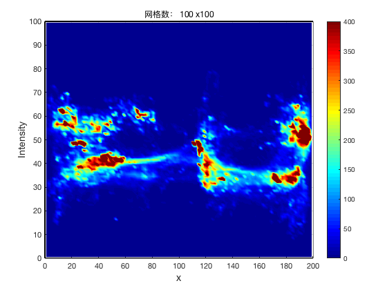

toc;

时间已过 21.717023 秒。

## 合并两个条件-1和3合并为1的方向

tic;

interval=10;

data=alldata{3};

data(:,2)=200-data(:,2);

data=[alldata{1};data];

% chisq test

disp(conditions{1}(10:end))

左：香蕉 右：5%异戊酸

for i=0:10:20

cutl=100-i;

cutr=100+i;

disp([cutl cutr])

[pvalue,st]=chit(data,cutl,cutr,expect(i/10+1,:))

end

100 100

pvalue = 0

st =

chi2stat: 1.7753e+03  
df: 1  
edges: [0 100 200]  
O: [81709 73340]  
E: [7.3425e+04 8.1624e+04]

90 110

pvalue = 0

st =

chi2stat: 1.8276e+03  
df: 1  
edges: [0 100 200]  
O: [80005 71650]  
E: [7.1693e+04 7.9962e+04]

80 120

pvalue = 5.3154e-06

st =

chi2stat: 20.7202  
df: 1  
edges: [0 100 200]  
O: [69740 68646]  
E: [6.8893e+04 6.9493e+04]

figure;

subplot(1,2,1)

hist(data(:,2),interval/2:interval:200-interval/2);

line([100 100],get(gca,'Ylim'),'linestyle',':')

title('x')

% y方向的分布

subplot(1,2,2)

hist(data(:,3));

title('y')

t=conditions{1};

suptitle(t(10:end));

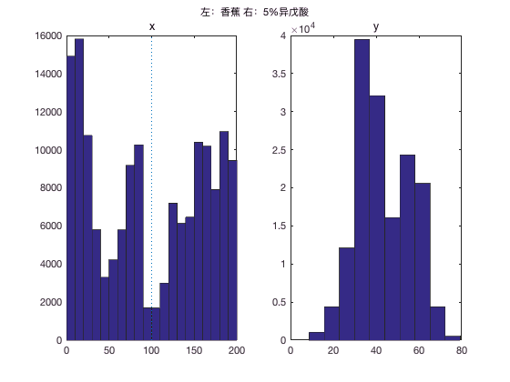

## 绘制热图

xx=data(:,2);

yy=data(:,3);

% sigma = 0.1;

gridSize = 100;

x=linspace(0,200,gridSize+1);

y=linspace(0,100,gridSize+1);

gridEval = zeros(length(x)-1,length(y)-1);

% 计算每个网格中点的频数

for cnt_x=1:length(x)-1

for cnt_y=1:length(y)-1

x_ind=xx>x(cnt_x) & xx<=x(cnt_x+1);

xy_ind=yy(x_ind)>y(cnt_y) & yy(x_ind)<=y(cnt_y+1);

gridEval(cnt_y, cnt_x)=length(yy(xy_ind));

end

end

% % 计算每个点处的高斯函数

% for i = 1:length(x)-1

% for j = 1:length(y)-1

% %calculate a Gaussian function on the grid with each point in the center and add them up

% gridEval(j,i) = gridEval(j,i) + sum(exp(-(((x(i)-xx).^2)./(2*sigma.^2) + ((y(j)-yy).^2)./(2*sigma.^2))));

% end

% end

% 绘制热图

figure;

surf((x(1:end-1)+ x(2:end))/2,(y(1:end-1)+y(2:end))/2,gridEval); view(2); shading interp;

% 增加z轴会变成三维的

% axis([0 200 0 100 0 100]);

axis([0 200 0 100])

h1 = gca; % 保存句柄，以便后面添加边框

set(gca, 'CLim', [0 400]);

% 添加标注

% title(['平滑散点图, \sigma = ' num2str(sigma) ', 网格数： ' num2str(gridSize) ' x' num2str(gridSize)],'Fontsize',14);

title([t(10:end) ' 网格数： ' num2str(gridSize) ' x' num2str(gridSize)]);

xlabel('x','Fontsize',14);

ylabel('y','Fontsize',14);

% 添加颜色条

colormap jet

colorbar;

ylabel('Intensity','Fontsize',14);

% 添加黑色的边框

axes(h1);

line(get(gca,'xlim'),repmat(min(get(gca,'ylim')),1,2),'color',[0 0 0],'linewidth',1);

line(get(gca,'xlim'),repmat(max(get(gca,'ylim')),1,2),'color',[0 0 0],'linewidth',2);

line(repmat(min(get(gca,'xlim')),1,2),get(gca,'ylim'),'color',[0 0 0],'linewidth',2);

line(repmat(max(get(gca,'xlim')),1,2),get(gca,'ylim'),'color',[0 0 0],'linewidth',1);

set(gcf,'color',[1 1 1],'paperpositionmode','auto');

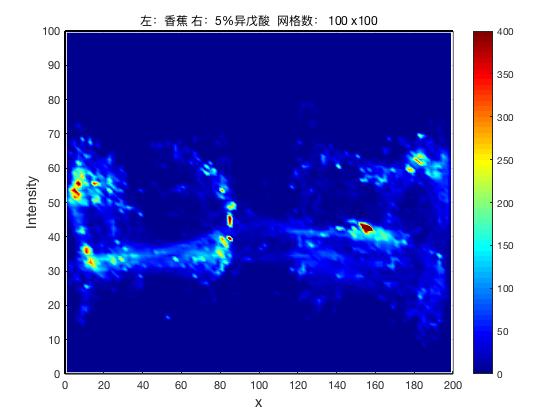

toc;

时间已过 14.522055 秒。

tic;

interval=10;

data=alldata{4};

data(:,2)=200-data(:,2);

data=[alldata{2};data];

% chisq test

disp(conditions{2}(10:end))

左：白桃 右：吲哚

for i=0:10:20

cutl=100-i;

cutr=100+i;

disp([cutl cutr])

[pvalue,st]=chit(data,cutl,cutr,expect(i/10+1,:))

end

100 100

pvalue = 1.0250e-12

st =

chi2stat: 50.7957  
df: 1  
edges: [0 100 200]  
O: [83735 96273]  
E: [8.5245e+04 9.4763e+04]

90 110

pvalue = 4.9151e-14

st =

chi2stat: 56.7635  
df: 1  
edges: [0 100 200]  
O: [81912 94703]  
E: [8.3493e+04 9.3122e+04]

80 120

pvalue = 0

st =

chi2stat: 1.9206e+03  
df: 1  
edges: [0 100 200]  
O: [71297 89571]  
E: [8.0086e+04 8.0782e+04]

figure;

subplot(1,2,1)

hist(data(:,2),interval/2:interval:200-interval/2);

line([100 100],get(gca,'Ylim'),'linestyle',':')

title('x')

% y方向的分布

subplot(1,2,2)

hist(data(:,3));

title('y')

t=conditions{2};

suptitle(t(10:end));

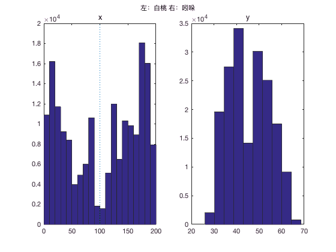

## 绘制热图

xx=data(:,2);

yy=data(:,3);

sigma = 0.1;

gridSize = 100;

x=linspace(0,200,gridSize);

y=linspace(0,100,gridSize);

gridEval = zeros(length(x)-1,length(y)-1);

% 计算每个网格中点的频数

for cnt_x=1:length(x)-1

for cnt_y=1:length(y)-1

x_ind=xx>x(cnt_x) & xx<=x(cnt_x+1);

xy_ind=yy(x_ind)>y(cnt_y) & yy(x_ind)<=y(cnt_y+1);

gridEval(cnt_y, cnt_x)=length(yy(xy_ind));

end

end

% % 计算每个点处的高斯函数

% for i = 1:length(x)-1

% for j = 1:length(y)-1

% %calculate a Gaussian function on the grid with each point in the center and add them up

% gridEval(j,i) = gridEval(j,i) + sum(exp(-(((x(i)-xx).^2)./(2*sigma.^2) + ((y(j)-yy).^2)./(2*sigma.^2))));

% end

% end

% 绘制热图

figure;

surf((x(1:end-1)+ x(2:end))/2,(y(1:end-1)+y(2:end))/2,gridEval); view(2); shading interp;

axis([0 200 0 100]);

h1 = gca; % 保存句柄，以便后面添加边框

% 设置颜色范围

set(gca, 'CLim', [0 400]);

% 添加标注

% title(['平滑散点图, \sigma = ' num2str(sigma) ', 网格数： ' num2str(gridSize) ' x' num2str(gridSize)],'Fontsize',14);

title([t(10:end) ' 网格数： ' num2str(gridSize) ' x' num2str(gridSize)]);

xlabel('x','Fontsize',14);

ylabel('y','Fontsize',14);

% 添加颜色条

colormap jet

colorbar;

ylabel('Intensity','Fontsize',14);

% 添加黑色的边框

axes(h1);

line(get(gca,'xlim'),repmat(min(get(gca,'ylim')),1,2),'color',[0 0 0],'linewidth',1);

line(get(gca,'xlim'),repmat(max(get(gca,'ylim')),1,2),'color',[0 0 0],'linewidth',2);

line(repmat(min(get(gca,'xlim')),1,2),get(gca,'ylim'),'color',[0 0 0],'linewidth',2);

line(repmat(max(get(gca,'xlim')),1,2),get(gca,'ylim'),'color',[0 0 0],'linewidth',1);

set(gcf,'color',[1 1 1],'paperpositionmode','auto');

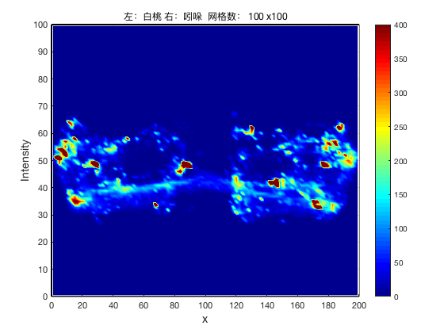

toc;

时间已过 15.251470 秒。

## 合并两个条件的（只取前面一段时间）

interval=10;

timeint=10;%minute

p1=1;

p2=timeint*60*1000/40;

% 1和3合并为1的方向

data=alldata{3};

data(:,2)=200-data(:,2);

data=[alldata{1}(p1:p2,:);data(p1:p2,:)];

data=data(data(:,2)<=50|data(:,2)>=150,:);

% chisq test

for i=0

cutl=100-i;

cutr=100+i;

disp([cutl cutr])

[pvalue,st]=chit(data,cutl,cutr)

end

100 100

pvalue = 5.7160e-136

st =

chi2stat: 615.9386  
df: 1  
edges: [0 100 200]  
O: [11229 7805]  
E: [9517 9517]

figure;

subplot(1,2,1)

hist(data(:,2),interval/2:interval:200-interval/2);

line([100 100],get(gca,'Ylim'),'linestyle',':')

title('x')

% y方向的分布

subplot(1,2,2)

hist(data(:,3));

title('y')

t=conditions{1};

suptitle(t(10:end));

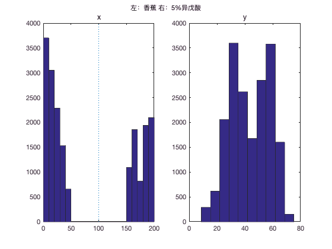

% 2和4合并为2的方向

data=alldata{4};

data(:,2)=200-data(:,2);

data=[alldata{2}(p1:p2,:);data(p1:p2,:)];

data=data(data(:,2)<=50|data(:,2)>=150,:);

% chisq test

for i=0

cutl=100-i;

cutr=100+i;

disp([cutl cutr])

[pvalue,st]=chit(data,cutl,cutr)

end

100 100

pvalue = 8.1480e-288

st =

chi2stat: 1.3145e+03  
df: 1  
edges: [0 100 200]  
O: [7596 12770]  
E: [10183 10183]

figure;

subplot(1,2,1)

hist(data(:,2),interval/2:interval:200-interval/2);

line([100 100],get(gca,'Ylim'),'linestyle',':')

title('x')

% y方向的分布

subplot(1,2,2)

hist(data(:,3));

title('y')

t=conditions{2};

suptitle(t(10:end));

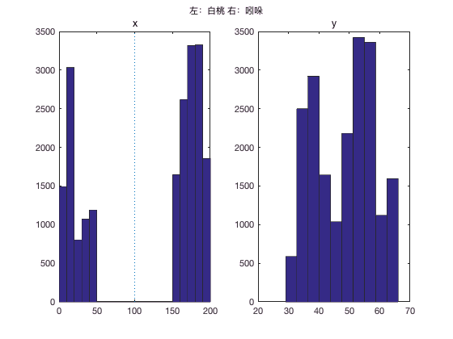

## 分时段的分布直方图

timeint=9.1;%minute

p=timeint*60*1000/40;

interval=5;

% plot each day

for f=1:length(files)

data=alldata{f};

l=length(data(:,2));

plots=ceil(l/p);

disp('===========================')

disp(conditions{f})

disp('===========================')

for j=0:10:50

timelab=zeros(1,l);

leftright=timelab;

cutl=100-j;

cutr=100+j;

leftright(data(:,2)<cutl)=1;

leftright(data(:,2)>cutl)=2;

for i=1:plots

timelab(p*(i-1)+1:min(p*i,l))=i;

end

timelab(leftright==0)=[];

leftright(leftright==0)=[];

[tbl,chi2,pvalue] = crosstab(timelab,leftright);

disp('-------------')

disp([num2str(cutl) '-' num2str(cutr)])

disp(tbl)

disp(chi2)

disp(pvalue)

disp('-------------')

% barplot

percenttbl=tbl./sum(tbl,2);

figure;

barh(percenttbl,'stack')

set(gca,'YDir','reverse')

title(conditions{f})

end

figure;

set(gcf,'position',[1280,720,ceil(plots/2)*400,2*300]);

% subplot each bin

for i=1:plots

subplot(2,ceil(plots/2),i)

hist(data(p*(i-1)+1:min(p*i,l),2),interval/2:interval:200-interval/2)

line([100 100],get(gca,'Ylim'),'linestyle',':')

% disp('-------------')

% disp([num2str(p*(i-1)+1) '-' num2str(min(p*i,l))])

%

% chisq test

for j=0%:10:20

cutl=100-j;

cutr=100+j;

% disp([cutl cutr])

[pvalue,st]=chit(data(p*(i-1)+1:min(p*i,l),:),cutl,cutr);

end

% disp('-------------')

title({[num2str(p*(i-1)+1) '-' num2str(min(p*i,l))];[num2str(cutl) '-' num2str(cutr) ' : ' num2str(st.O)]})

end

suptitle({conditions{f};''});

end

===========================

20200708 左：香蕉 右：5%异戊酸

===========================

-------------

100-100

7028 6622  
5603 8047  
6616 7034  
6366 7284  
3900 6545

642.5313

9.6454e-138

-------------

-------------

90-110

6713 6937  
5503 8147  
6505 7145  
6273 7377  
3800 6645

562.5295

1.9903e-120

-------------

-------------

80-120

6443 7207  
5313 8337  
6363 7287  
6068 7582  
3624 6821

568.5360

9.9824e-122

-------------

-------------

70-130

5773 7877  
4825 8825  
5335 8315  
5570 8080  
3360 7085

348.5363

3.6308e-74

-------------

-------------

60-140

5025 8625  
4111 9539  
4864 8786  
4969 8681  
3139 7306

263.7687

7.0278e-56

-------------

-------------

50-150

4606 9044  
3526 10124  
4456 9194  
4362 9288  
2973 7472

270.6469

2.3139e-57

-------------

===========================

20200709 左：白桃 右：吲哚

===========================

-------------

100-100

4554 9096  
4828 8822  
6220 7430  
8235 5415  
8580 5070  
6611 7039  
3512 4592

4.1729e+03

0

-------------

-------------

90-110

4336 9314  
4709 8941  
6119 7531  
8175 5475  
8343 5307  
6446 7204  
3458 4646

4.2048e+03

0

-------------

-------------

80-120

3991 9659  
4552 9098  
5886 7764  
8119 5531  
7782 5868  
6205 7445  
3296 4808

4.1461e+03

0

-------------

-------------

70-130

3716 9934  
4282 9368  
5702 7948  
8059 5591  
7425 6225  
5805 7845  
2827 5277

4.5146e+03

0

-------------

-------------

60-140

3332 10318  
3937 9713  
5517 8133  
7986 5664  
7106 6544  
5455 8195  
2134 5970

5.5117e+03

0

-------------

-------------

50-150

2889 10761  
3462 10188  
5252 8398  
7865 5785  
6621 7029  
4671 8979  
1807 6297

6.3698e+03

0

-------------

===========================

20200715 左：5%异戊酸 右：香蕉

===========================

-------------

100-100

4964 8686  
4356 9294  
6805 6845  
5887 7763  
5788 7862  
5975 7675  
4033 4071

1.3199e+03

5.3326e-282

-------------

-------------

90-110

4832 8818  
4091 9559  
6710 6940  
5777 7873  
5713 7937  
5857 7793  
3919 4185

1.4549e+03

3.1179e-311

-------------

-------------

80-120

4667 8983  
3525 10125  
6540 7110  
5607 8043  
5603 8047  
5719 7931  
3280 4824

1.6905e+03

0

-------------

-------------

70-130

4402 9248  
3234 10416  
6249 7401  
5019 8631  
5462 8188  
5489 8161  
2604 5500

1.8027e+03

0

-------------

-------------

60-140

4107 9543  
2914 10736  
5569 8081  
4655 8995  
5222 8428  
5229 8421  
2300 5804

1.6835e+03

0

-------------

-------------

50-150

3639 10011  
2681 10969  
4130 9520  
4077 9573  
4768 8882  
4597 9053  
2114 5990

1.0459e+03

1.0746e-222

-------------

===========================

20200716 左：吲哚 右：白桃

===========================

-------------

100-100

7474 6176  
6353 7297  
6100 7550  
10038 3612  
7181 6469  
6743 6907  
4920 3184

3.1574e+03

0

-------------

-------------

90-110

7358 6292  
6247 7403  
5772 7878  
10031 3619  
6992 6658  
6619 7031  
4888 3216

3.5233e+03

0

-------------

-------------

80-120

7039 6611  
6161 7489  
5372 8278  
10024 3626  
6638 7012  
6329 7321  
4833 3271

4.0611e+03

0

-------------

-------------

70-130

6774 6876  
6057 7593  
4878 8772  
10012 3638  
4671 8979  
5751 7899  
4787 3317

6.0472e+03

0

-------------

-------------

60-140

6567 7083  
5971 7679  
4510 9140  
10000 3650  
3283 10367  
4979 8671  
4731 3373

8.6719e+03

0

-------------

-------------

50-150

5686 7964  
5573 8077  
4104 9546  
6302 7348  
2618 11032  
3703 9947  
3558 4546

3.5177e+03

0

-------------

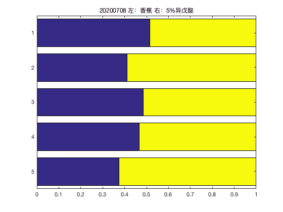

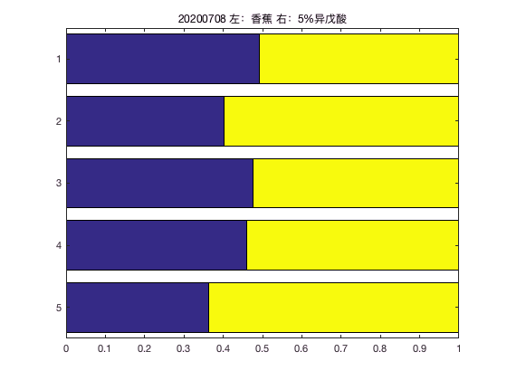

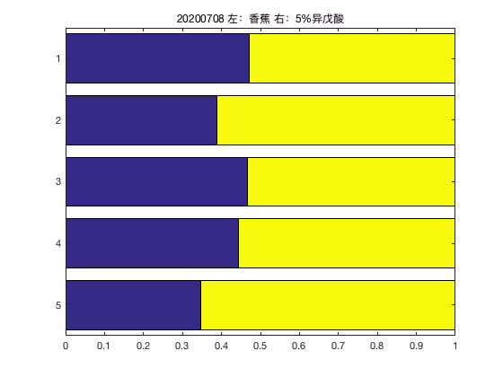

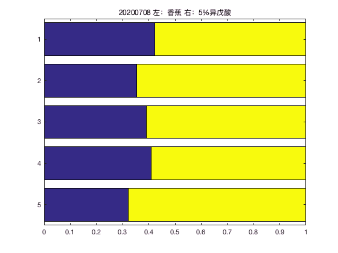

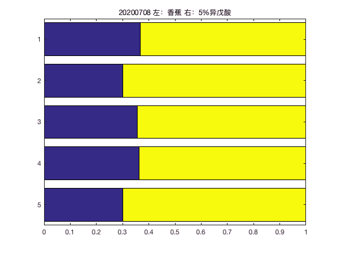

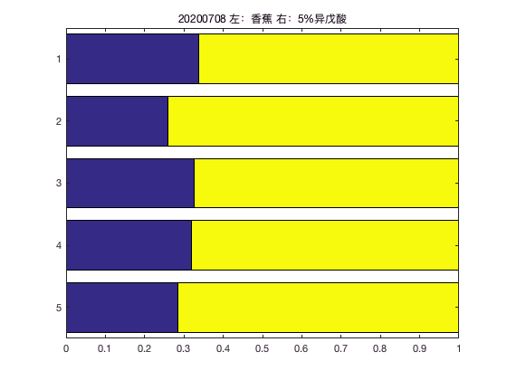

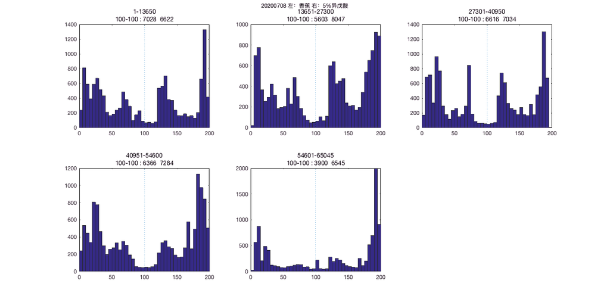

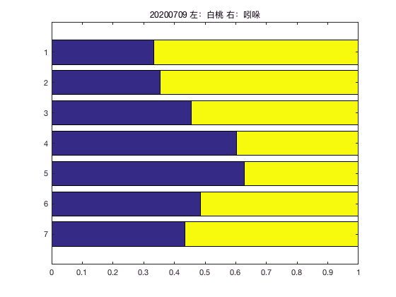

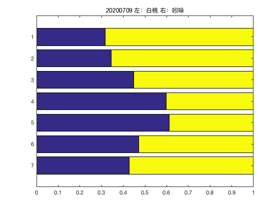

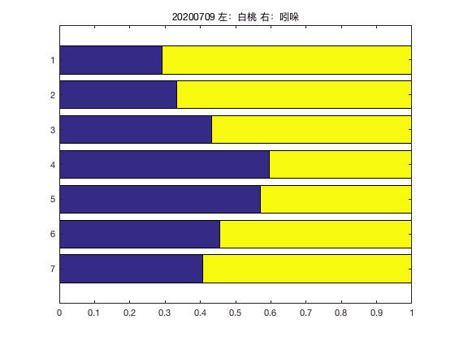

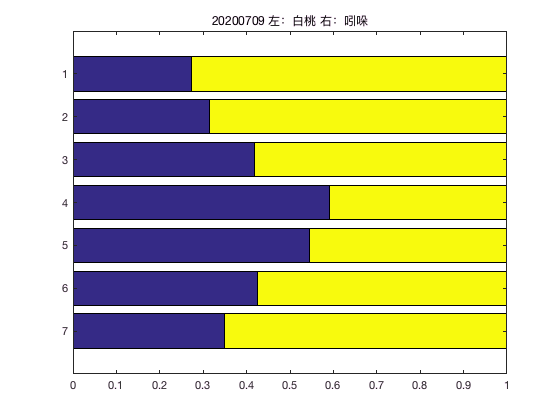

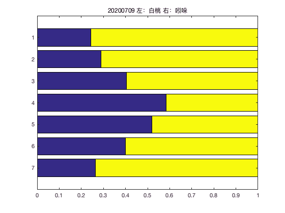

[16 more figures not shown]

## 绘制热图的例子 生成数据

% z = [repmat([1 2],1000,1) + randn(1000,2)*[1 .5; 0 1.32];...

% repmat([9 1],1000,1) + randn(1000,2)*[1.4 .2; 0 0.98];...

% repmat([4 8],1000,1) + randn(1000,2)*[1 .7; 0 0.71];];

%

% figure('units','normalized','position',[ 0.4458 0.6296 0.1995 0.2759]);

% plot(z(:,1),z(:,2),'.');

% title({'原始数据','散点视图有显著的重叠'});

% set(gcf,'color',[1 1 1],'paperpositionmode','auto');

## 绘制热图

% xx = z(:,1);

% yy = z(:,2);

% sigma = 0.1;

% gridSize = 100;

%

% % 选择colormap

% colormap(summer);

%

% x=linspace(min(xx),max(xx),gridSize);

% y=linspace(min(yy),max(yy),gridSize);

% gridEval = zeros(length(x)-1,length(y)-1);

%

% % 计算每个点处的高斯函数

% for i = 1:length(x)-1

% for j = 1:length(y)-1

% %calculate a Gaussian function on the grid with each point in the center and add them up

% gridEval(j,i) = gridEval(j,i) + sum(exp(-(((x(i)-xx).^2)./(2*sigma.^2) + ((y(j)-yy).^2)./(2*sigma.^2))));

% end

% end

%

% % 绘制热图

% figure;

% surf((x(1:end-1)+ x(2:end))/2,(y(1:end-1)+y(2:end))/2,gridEval); view(2); shading interp;

% axis([min(xx),max(xx) min(yy),max(yy)]);

% h1 = gca; % 保存句柄，以便后面添加边框

%

% % 添加标注

% title(['平滑散点图, \sigma = ' num2str(sigma) ', 网格数： ' num2str(gridSize) ' x' num2str(gridSize)],'Fontsize',14);

% xlabel('x','Fontsize',14);

% ylabel('y','Fontsize',14);

%

% % 添加颜色条

% colorbar;

% ylabel('Intensity','Fontsize',14);

%

% % 添加黑色的边框

% axes(h1);

% line(get(gca,'xlim'),repmat(min(get(gca,'ylim')),1,2),'color',[0 0 0],'linewidth',1);

% line(get(gca,'xlim'),repmat(max(get(gca,'ylim')),1,2),'color',[0 0 0],'linewidth',2);

% line(repmat(min(get(gca,'xlim')),1,2),get(gca,'ylim'),'color',[0 0 0],'linewidth',2);

% line(repmat(max(get(gca,'xlim')),1,2),get(gca,'ylim'),'color',[0 0 0],'linewidth',1);

%

% set(gcf,'color',[1 1 1],'paperpositionmode','auto');

% %% 绘制运动的点

% % 最简单的动画形式，使用comet、comet3函数

% % 产生一个顺着曲线轨迹运动的质点

% % step1：求解出质点完整的运动轨迹坐标x，y和z

% % step2：使用comet或者comet3直接绘制动点

% % 使用函数comet建立质点绕圆运动的动画

% clc;clear;

% %{

% linspace是Matlab中的一个指令，用于产生指定范围内的指定数量点数，相邻数据跨度相同，并返回一个行向量。

% 调用方法：linspace(x1,x2,N)

% 功 能：用于产生x1，x2之间的N点行矢量，相邻数据跨度相同。其中x1、x2、N分别为起始值、终止值、元素个数。若缺省N，默认点数为100。

% 举例如下：X = linspace(5, 100, 20) % 产生从5到100范围内的20个数据，相邻数据跨度相同

% X = 5 10 15 20 25 30 35 40 45 5055 60 65 70 75 80 85 90 95 100 ps：这和X = [5 : 5 : 100]的效果是一样的。

% %}

% % 圆周运动

% t = linspace(0, 2*pi, 10000);

% x = cos(t);

% y = sin(t);

% % 以便比较comet是否跟着轨迹走

% % plot(x, y);

% axis([-1, 1 -1, 1]); axis square;

% hold on; grid on;

% % comet(x, y, p); p：定义轨迹尾巴的长度，范围在0-1之间，默认时为0.1

% comet(x, y, 0.03);

%

%

% % 平抛运动

% clf;

% clear;

% grid on;

% vx = 40;

% dt = linspace(0,10,1000);

% dx = vx*dt;

% dy = -9.8*dt.^2/2;

% comet(dx, dy);

%

%

% % 导弹发射

% clf;

% clear;

% grid on;

% vx = 100*cos(1/4*pi);

% vy = 100*sin(1/4*pi);

% t = 0:0.01:15;

% dx = vx*t;

% dy = vy*t-9.8*t.^2/2;

% comet(dx, dy);

% % 使用函数comet3建立质点绕圆运动的动画

% figure();

% grid on;

% tt = 0:pi/500:10*pi;

% plot3(sin(t),cos(t),t);

% comet3(sin(tt), cos(tt), tt, 0.5);

%

% %% 制作动画

% clc; clear;

% % peaks是一个函数，其中有2个变量。由平移和放缩高斯分布函数获得。

% % 参数为30，得到的X、Y、Z为30*30的矩阵。

% [X, Y, Z] = peaks(30);

% % surf绘制三维曲面图

% surf(X,Y,Z);

% axis([-3,3,-3,3,-10,10]);

% % 关闭所用坐标轴上的标记、格栅和单位标记。但保留由text和gtext设置的对象

% axis off;

% %{

% shading：是用来处理色彩效果的，分以下三种：

% 1、no shading 一般的默认模式 即shading faceted

% 2、shading flat 在faceted的基础上去掉图上的网格线

% 3、shading interp 在flat的基础上进行色彩的插值处理，使色彩平滑过渡

% %}

% shading interp;

% %{

% colormap：设定和获取当前的色图。

% 1、colormap(map)：设置颜色图为矩阵map。如果map中的任何值在区间[0,1]之外，MATLAB返回错误。

% 2、colormap('default')：将当前的颜色图设置为默认的颜色图。

% 3、cmap=colormap：返回当前的颜色图。返回的值都在区间[0,1]内。

% map是一个3列矩阵，其元素数值定义在区间[0,1]。矩阵的每行元素表示1一个真色彩向量，即红、绿、蓝3基色的系数。

% jet为matlab中预定义的色图样式中的一种，表示：黑、红、黄、白色浓淡交错。

% %}

% colormap(jet);

% % 建立一个20列的大矩阵

% M = moviein(20);

% for i = 1:20

% % 改变视点

% view(-37.5+24*(i-1),30);

% % 将图形保存到M矩阵

% M(i) = getframe;

% end

% % 播放画面2次

% movie(M,2);

% %% 动态绘制椭圆

% clc;

% axis([-2,2,-2,2]);

% % axis square 当前坐标系图形设置为方形，刻度范围不一定一样，但是一定是方形的。

% % axis equal 将横轴纵轴的定标系数设成相同值，即单位长度相同，刻度是等长的，但不一定是方形的。

% axis equal;

% grid on;

% h = animatedline('Marker', 'o', 'color', 'b', 'LineStyle', 'none');

% t = 6*pi*(0:0.02:1);

% for n = 1:length(t)

% addpoints(h, 2*cos(t(1:n)),sin(t(1:n)));

% % 一般是为了动态观察变化过程 pause（a）暂停a秒后执行下一条指令

% pause(0.05);

% % 可以用drawnow update加快动画速度

% drawnow update;

% end